# ST558 - Project 1 - XML Vignette

Peter Scarbrough

October 16, 2019

*This vignette is designed to introduce the XML file format and explore how to work with it in R.*

# XML File Format

XML (eXtensible Markup Language) is a standardized open-source data standard for sharing arbitrary data structures across the internet. It was developed in 1998 by the [World Wide Web Consortium](https://en.wikipedia.org/wiki/World_Wide_Web_Consortium). An XML file is a string of text where data are stored weakly typed (all as character values) and referenced (marked up) by tags (i.e. values enclose by brackets: < >). Use of white space in an XML file is optional and mostly just to make it more readable by humans. An example of XML code is shown below:

```r
<Data>
  <Person>
    <Name>John Smith</Name>
    <Phone>555-555-5555</Phone>
  </Person>
  <Person>
    <Name>Jane Smith</Name>
    <Phone>555-555-5555</Phone>
  </Person>
<Data>
```

XML files can represent something easily coerced into a 2D data set or they can be hierarchical, containing any amount of nested data structures. This makes them a convenient store of typical internet data, since they are easy to collect and share. However, this also makes XML files challenging to read and parse correctly. Because XML files are such a standard way of representing data, many API and sources of internet data will use the XML file format. There are many tutorials available on the web to learn more about XML: e.g. [w3schools.com](https://www.w3schools.com/xml/default.asp)

# XML Packages in R

There are two main packages for reading XML files:

1. [XML](https://cran.r-project.org/web/packages/XML/XML.pdf)
2. [xml2](https://cran.r-project.org/web/packages/xml2/xml2.pdf)

Both packages can accomplish the basic functions of reading and writing XML files. `XML` is no longer actively maintained but has a larger selection of functions (mostly for internal operations) to aid in flexible parsing of XML files. The `xml2` package is still actively maintained and has a more consistent and modern R syntax with a smaller and more intuitive array of functions. It also has better memory management. Because of this, I have elected to use the `xml2` package for the following example.

Since XML file structure is arbitrary there is no function that can automate all the aspects of XML file reading and parsing. Instead, XML packages come equipped with tools that allow one to interrogate the tree structure of the XML file and then use that information to parse out the information that is needed. Correspondingly, `xml2` comes equipped with functions that are generally light on features, performing mostly basic tasks with usually 0-2 key options. When wanting to read and parse XML files, one should familiarize themselves with many of these functions which will act as tools as part of a larger process.

## Key functions in `xml2`

### For Reading XML Data

| Function | Description | Key Option=Default | Option Description |
| --- | --- | --- | --- |
| `read_xml` | Accepts string, file path, or url argument. Returns XML data object | as_html=FALSE | Species whether to read as HTML |
| `download_xml` | Accepts url argument. Downloads files to working directory. | file=basename(url) | Name to download file as |
| . | . | mode=“wb” | Write mode: ‘w’(write), ‘wb’(write binary), ‘a’(append) |

### For Navigating XML Tree Structure

*All of the following functions accept an XML document, node or node set as an argument*

| Function | Description | Key Option | Option Description |
| --- | --- | --- | --- |
| `xml_children` | Returns list of elements downstream from current node | . | . |
| `xml_child` | Returns list of 1st or `search`-specified element downstream from current node | `search`=1 | Specifies which child node to search |
| `xml_parents` | Returns list of all parent elements from current node | . | . |
| `xml_parent` | Returns list of parent elements one-level up from current node | . | . |
| `xml_contents` | Returns list of contents from current node | . | . |
| `xml_length` | Returns length of each element from current node | `only_elements`=TRUE |  |
| `xml_root` | Returns the root node | . | . |

### For Parsing XML Data

| Function | Description | Key Option | Option Description |
| --- | --- | --- | --- |
| `as_list` | Converts XML document or node set to equivalent R list | . | . |

### Summary

While the `xml2` package contains additional functions and the functions listed can contain additional arguments, for the sake of clarity and brevity, I have tried to list only the key functions and features. For more detailed information one can consult the `xml2` [online documentation](https://cran.r-project.org/web/packages/xml2/xml2.pdf).

# Example XML Data Set

The following XML data set was found from a catalog of freely-available, public US government data. The data set stores demographic and graduation outcomes from 2001-2015, classes 2005 through 2015, in the city of New York, NY. The data set was chosen due to my personal interest in education and due to moderate balance bewteen simplicity/complexity, which seemed to be a good starting point when learning XML file structure and R’s XML parsing tools.

## Metadata

| Feature | Notes |
| --- | --- |
| Data | **2005 - 2015 Graduation Outcomes** |
| Filename | “rows.xml” |
| Publisher | NYC OpenData [(data.cityofnewyork.us)](https://opendata.cityofnewyork.us/) |
| Repository | https://catalog.data.gov |
| URL | https://catalog.data.gov/dataset/regents-exam-results |
| Download Date | October 11, 2019 |
| Description | Contains graduation outcome data from 2001-2015, classes 2005 through 2015. Cohorts and demographics of New York City students for each year are tracked over various cohort lengths. Total students, to… |
| Source | Public Government Records |
| Dimensions | 430 rows, 22 columns |

## Variables

| Variable Name | Label | Type |
| --- | --- | --- |
| cohort_year | Cohort Year | Numeric |
| cohort_category | Cohort Category | Character |
| demographic | Demographic | Character |
| total_cohort | # Total Cohort | Numeric |
| tota_grads | # Total Grads | Numeric |
| of_cohort_total_grads_1 | % of cohort Total Grads | Numeric |
| of_cohort_total_grads_2 | # of cohort Total Grads | Numeric |
| of_cohort_total_regents | % of cohort Total Regents | Numeric |
| of_grads_total_regents_1 | % of grads Total Regents | Numeric |
| of_grads_total_regents_2 | # of grads Total Regents | Numeric |
| of_cohort_advanced_regents | % of cohort Advanced Regents | Numeric |
| of_grads_advanced_regents_1 | % of grads Advanced Regents | Numeric |
| of_grads_advanced_regents_2 | # of grads Advanced Regents | Numeric |
| of_cohort_regents_w_o_advanced | % of cohort Regents w/o Advanced | Numeric |
| of_grads_regents_w_o_advanced_1 | % of grads Regents w/o Advanced | Numeric |
| of_grads_regents_w_o_advanced_2 | # of grads Regents w/o Advanced | Numeric |
| of_cohort_local | % of cohort Local | Numeric |
| of_grads_local | % of grads Local | Numeric |
| still_enrolled | # Still Enrolled | Numeric |
| of_cohort_still_enrolled | % of cohort Still Enrolled | Numeric |
| dropped_out | # Dropped Out | Numeric |
| of_cohort_dropped_out | % of cohort Dropped Out | Numeric |

Special Notes: The data contain summary level measures for each demographic group. Demographic group contains race, gender, english-speaking, and disability information for student. Importantly, there is insufficient information to factor out different levels of demographic variables outside of the same feature (e.g. one can figure the measures for a cohort for whites and separately for a cohort for males, but the data can not be used to figure the measures for a cohort of white males). Thus, special care should be taken in manipulating and handling the demographic data.

## Loading the Data

The XML file is downloaded to the working directory with `download_xml` and then opened using `read_xml`. Since this is just a standard XML file, the default options to both functions are acceptable.

```r
# loading required packages
library(xml2)       # for xml reading, parsing package
library(tidyverse)  # for standard data manipualtion
library(knitr)      # for access to advanced R markdown functions
library(DT)         # for advanced datatable printing in HTML

# setting chunk options
opts_chunk$set(warning=F, message=F)

# Downloading and loading XML Data
# Download Date: October 11, 2019
download_xml("https://data.cityofnewyork.us/api/views/qk7d-gecv/rows.xml")
xmlData <- read_xml("rows.xml")
```

## Identifying XML Data Structure

The `xmlData` object is still in a fairly raw data structure. What `read_xml` basically did was parse the tags in the character data to construct a hierarchical list of nodes containing either more nodes or data. The goal now is to investigate the structure of the data, figure out what it contains, and use that information to effectively parse it.

If a person was impatient or simply very familiar with R list objects and wanted to only know the bare minimum of the `xml2` package, they could drop the XML data object into the function `as_list` right now and return an R list object. A person could then investigate and parse the information from list to data frame. However, `xml2` contains fairly intuitive functions specifically designed to investigate XML file structure; therefore, it often makes more sense to investigate the structure of XML object with these set of functions, and once that has been figured, drop the parts of the XML object that are needed into an R list and translate into a data frame from there. This is the approach that will be taken below:

```r
# identify XML structure
# 1st level structure
level1 <- xml_children(xmlData)
length(level1)             # number of nodes in 1st level heirarchy
```

```
## [1] 1
```

```r
xml_name(level1)           # names of nodes
```

```
## [1] "row"
```

```r
xml_length(level1)         # how many nodes are contained in each 1st level node
```

```
## [1] 430
```

```r
# 2nd level structure
level2 <- xml_children(level1)
length(level2)             # number of nodes in 2nd level hierarchy
```

```
## [1] 430
```

```r
xml_name(level2)[1]        # name of first node
```

```
## [1] "row"
```

```r
unique(xml_name(level2))   # all unique names in 2nd level (note: they are all the same)
```

```
## [1] "row"
```

```r
xml_length(level2)         # how many nodes are contained within each 2nd level node
```

```
##   [1] 22 22 22 22 22 22 22 22 22 22 16 22 22 22 22 22 22 22 22 22 22 22 22
##  [24] 22 22 22 22 22 22 22 22 22 22 22 22 16 22 22 22 22 22 22 22 22 22 22
##  [47] 22 22 22 22 22 22 22 22 16 22 22 22 22 22 22 22 22 22 22 22 22 22 22
##  [70] 22 22 22 22 22 22 22 22 22 22 22 22 22 22 22 22 22 22 22 22 22 22 22
##  [93] 22 22 22 22 22 16 22 22 22 22 22 22 22 22 22 22 22 22 22 22 22 22 22
## [116] 22 22 22 22 22 22 22 22 22 22 22 22 22 22 22 22 22 22 22 22 22 22 22
## [139] 22 22 16 22 22 22 22 22 22 22 22 22 22 22 22 22 22 22 22 22 22 22 22
## [162] 22 22 22 22 22 22 22 22 22 22 22 22 22 22 22 22 22 22 22 22 22 22 16
## [185] 22 22 22 22 22 22 22 22 22 22 22 22 22 22 22 22 22 22 22 22 22 22 22
## [208] 22 22 22 22 22 22 22 22 22 22 22 22 22 22 22 22 22 22 22 16 22 22 22
## [231] 22 22 22 22 22 22 22 22 22 22 22 22 22 22 22 22 22 22 22 22 22 22 22
## [254] 22 22 22 22 22 22 22 22 22 22 22 22 22 22 22 22 16 22 22 22 22 22 22
## [277] 22 22 22 22 22 22 22 22 22 22 22 22 22 22 22 22 22 22 22 22 22 22 22
## [300] 22 22 22 22 22 22 22 22 22 22 22 22 22 16 22 22 22 22 22 22 22 22 22
## [323] 22 22 22 22 22 22 22 22 22 22 22 22 22 22 22 22 22 22 22 22 22 22 22
## [346] 22 22 22 22 22 22 22 22 22 22 16 22 22 22 22 22 22 22 22 22 22 22 22
## [369] 22 22 22 22 22 22 22 22 22 22 22 22 22 22 22 22 22 22 22 22 22 22 22
## [392] 22 22 22 22 22 22 22 22 22 22 22 22 22 22 22 22 22 22 22 22 22 22 22
## [415] 22 22 22 22 22 22 22 22 22 22 22 22 22 22 22 22
```

```r
# 3rd level structure
level3 <- xml_children(level2)
length(level3)             # number of nodes in 3rd level hierarchy
```

```
## [1] 9400
```

```r
uniqueNames <- unique(xml_name(level3))  # unique names in 3rd level nodes
uniqueNames                # the unique names of nodes in 3rd level nodes
```

```
##  [1] "cohort_year"                     "cohort_category"
##  [3] "demographic"                     "total_cohort"
##  [5] "total_grads"                     "of_cohort_total_grads_1"
##  [7] "of_cohort_total_grads_2"         "of_cohort_total_regents"
##  [9] "of_grads_total_regents_1"        "of_grads_total_regents_2"
## [11] "of_cohort_advanced_regents"      "of_grads_advanced_regents_1"
## [13] "of_grads_advanced_regents_2"     "of_cohort_regents_w_o_advanced"
## [15] "of_grads_regents_w_o_advanced_1" "of_grads_regents_w_o_advanced_2"
## [17] "of_cohort_local"                 "of_grads_local"
## [19] "still_enrolled"                  "of_cohort_still_enrolled"
## [21] "dropped_out"                     "of_cohort_dropped_out"
```

```r
length(uniqueNames)        # how many unique names there are in 3rd level node
```

```
## [1] 22
```

```r
sum(xml_length(level3))    # how many nodes there are to find after 3rd level nodes
```

```
## [1] 0
```

From this we can work out that the XML file has 3 nested levels:

- 1st level: Root node: Contains set of rows
- 2nd level: 430 Rows: Each contains either 22 or 16 nodes (columns) each
- 3rd level: 9400 RowxColumn Cells: Data for each row x cell combination

From this we can figure our data is essentially a 2D data set with 430 rows and 22 columns of data. Some rows only have 16 columns of data, which reflects missing data. Now that we understand the data structure we can begin parsing the XML file into a data frame.

## Converting XML Data to Data Frame

Now that XML file structure has been figured, it is easy to drop the XML object into `as_list` which will return an R list object. From there, the R list object can be manipulated into a data frame and then analysis performed per usual. In the cases of very large XML files, it would be a good idea to only drop the necessary parts of the XML file into `as_list`. To do this, one would only need to further delve into the structure to figure out which nodes they want and then subset appropriately. Note: `as_list` would work just as well with `level3` as an argument as `xmlData`. However, in this case, since the XML data is relatively small, it doesn’t hurt to just drop the entire XML object into `as_list`.

```r
# Convert XML data to list
xmlList <- as_list(xmlData)

# Subset to the row-level data
xmlRows <- xmlList[[1]][[1]]

# Get column names, row number
myNames <- unique(unlist(sapply(xmlRows, function(x) names(x))))
nRows   <- length(xmlRows)

# initialize empty data frame
myData <- data.frame()
for(j in myNames) myData[[j]] <- character()

# populate data frame with XML data
for(row in 1:nRows){
  tempList <- list()
  # initialize temp list with missing data
  for(name in myNames){
    tempList[[name]] <- as.character(NA)
  }
  # fill with XML data if available
  for(col in names(xmlRows[[ row]])){
    tempList[[col]] <- unlist(xmlRows[[ row]][[col]])
  }
  myData <- rbind(myData, tempList, stringsAsFactors=F)
}

# Print part of data frame for Q/C check
library(DT)
datatable(head(myData), options = list(scrollY="400px", scrollX="400px"))
```

|  | cohort_year | cohort_category | demographic | total_cohort | total_grads | of_cohort_total_grads_1 | of_cohort_total_grads_2 | of_cohort_total_regents | of_grads_total_regents_1 | of_grads_total_regents_2 | of_cohort_advanced_regents | of_grads_advanced_regents_1 | of_grads_advanced_regents_2 | of_cohort_regents_w_o_advanced | of_grads_regents_w_o_advanced_1 | of_grads_regents_w_o_advanced_2 | of_cohort_local | of_grads_local | still_enrolled | of_cohort_still_enrolled | dropped_out | of_cohort_dropped_out |
| --- | --- | --- | --- | --- | --- | --- | --- | --- | --- | --- | --- | --- | --- | --- | --- | --- | --- | --- | --- | --- | --- | --- |
| 1 | 2001 | 4 Year June | English Language Learner | 10540 | 2791 | 26.50 | 992 | 9.00 | 35.50 | 315 | 3.00 | 11.30 | 677 | 6.40 | 24.30 | 1803 | 17.10 | 64.60 | 3895 | 37.00 | 3220 | 30.60 |
| 2 | 2001 | 5 Year June | English Language Learner | 10540 | 3920 | 37.20 | 1233 | 11.70 | 31.50 | 371 | 3.50 | 9.50 | 862 | 8.20 | 22.00 | 2701 | 25.60 | 68.90 | 1516 | 14.40 | 4193 | 39.80 |
| 3 | 2001 | 6 Year | English Language Learner | 10540 | 4296 | 40.80 | 1291 | 12.20 | 30.10 | 380 | 3.60 | 8.80 | 911 | 8.60 | 21.20 | 3028 | 28.70 | 70.50 | 655 | 6.20 | 4598 | 43.60 |
| 4 | 2002 | 4 Year June | English Language Learner | 7454 | 1691 | 22.70 | 639 | 8.60 | 37.80 | 132 | 1.80 | 7.80 | 507 | 6.80 | 30.00 | 1062 | 14.20 | 62.80 | 3062 | 41.10 | 2330 | 31.30 |
| 5 | 2002 | 5 Year June | English Language Learner | 7454 | 2354 | 31.60 | 794 | 10.70 | 33.70 | 176 | 2.40 | 7.50 | 618 | 8.30 | 26.30 | 1578 | 21.20 | 67.00 | 1457 | 19.50 | 3041 | 40.80 |
| 6 | 2002 | 6 Year | English Language Learner | 7454 | 2729 | 36.60 | 856 | 11.50 | 31.40 | 185 | 2.50 | 6.80 | 671 | 9.00 | 24.60 | 1891 | 25.40 | 69.30 | 697 | 9.40 | 3356 | 45.00 |

## Fixing Data Types with Custom Function

The data appear to have been parsed from the XML correctly. In the XML file, data are stored as characters, which is how they were read into the data frame. For the next step the data will be coerced into their correct types. To do this, a custom function will be created to detect data type and apply it to the data frame.

```r
# define custom function - detectFixType
#   takes 1 argument - array of character data
#   returns 1 argument - array of character or numeric data
#   description: detects and sets col type (numeric vs chr)
detectFixType <- function(a){
   tryCatch(
     {as.numeric(a)},
     error=function(x){
       return(as.character(a))
       },
     warning=function(x){
       return(as.character(a))
       },
     finally=function(x){
       return(as.numeric(a))
     }
     )
}

# corrects data types in data frame
myData <- sapply(myData, detectFixType, simplify=F) %>% as.data.frame()

# check data frame types
sapply(myData, class)
```

```
##                     cohort_year                 cohort_category
##                       "numeric"                        "factor"
##                     demographic                    total_cohort
##                        "factor"                       "numeric"
##                     total_grads         of_cohort_total_grads_1
##                       "numeric"                       "numeric"
##         of_cohort_total_grads_2         of_cohort_total_regents
##                       "numeric"                       "numeric"
##        of_grads_total_regents_1        of_grads_total_regents_2
##                       "numeric"                       "numeric"
##      of_cohort_advanced_regents     of_grads_advanced_regents_1
##                       "numeric"                       "numeric"
##     of_grads_advanced_regents_2  of_cohort_regents_w_o_advanced
##                       "numeric"                       "numeric"
## of_grads_regents_w_o_advanced_1 of_grads_regents_w_o_advanced_2
##                       "numeric"                       "numeric"
##                 of_cohort_local                  of_grads_local
##                       "numeric"                       "numeric"
##                  still_enrolled        of_cohort_still_enrolled
##                       "numeric"                       "numeric"
##                     dropped_out           of_cohort_dropped_out
##                       "numeric"                       "numeric"
```

The XML data object has been successfully parsed into a data frame and the data appear to have been changed to the correct type. At this point, the analysis of XML data can be conducted per usual R practice.

# Analysis of XML Data

## Analysis Goals

The goals of this analysis are to examine the relationship between demographic trends and graduation rate over time. Since this is a preliminary investigation, the approach will be simplified: data will be subset to only consider race and gender information at this stage, leaving other demographic information for a potential future investigation. As secondary investigations, the rates of high school dropping out will also be investigated as a function of demographic status over time.

We will therefore consider the following variables of interest: Cohort year and graduation/drop out rates as **quantiative (numeric) variables**. And `cohort_category` and `demographic` data as **categorical (factor) variables**. As a quality control check, a rate of missingness to follow-up variable will also be computed from the data and treated as an additional quantitative variable of interest.

## Preparing the data

### Getting Race and Gender Subsets

Demographic data have overlapping categories, making it impossible to compare all the categories to each other simultaneously (i.e. there is no information in the data to suggest who is male and also white, or black and also female – only single demographic data are present). As a result of these limitations, it makes more sense to think of the demographic data separately into their complementary categories to the point where a natural next step is to segregate the different types of demographic data into separate, complementary data sets. For the purpose of conducting a preliminary analysis, the data will be subsetted into the categories of race and gender

In order to have a natural reference category for preliminary analysis, a total category of all genders combined or all races combined will be calculated and also included in the subsetted data. This will be achieved through the creation of another custom function.

```r
# get subsets
genderData <- filter(myData, demographic %in% c("Male", "Female"))
raceData   <- filter(myData, demographic %in% c("Asian", "Black", "Hispanic", "White"))

# define custom function - detectFixType
# purpose: creates a total category from factor subsets and automatically sums cols
#    e.g.: (gender=c("male", "female"), data=c(1,3)) appends row (gender="Total", data=4)
#   takes 3 arguments -
#     - data frame with a factor column with subset categories (no total)
#     - name of factor variable
#     - key variables (e.g. cohort_year)
#     - name(s) of columns to sum
#   returns 1 argument
#     - data set with factor subset that includes total category + col sums
getTotalFactor <- function(data, factorVar, keyCols, colsToSum){
  # group data by keys, summarize to get total column sums
  totalData <- genderData %>%
    group_by(.dots=keyCols) %>%
    summarize_at(colsToSum, sum) %>%
    mutate(!!factorVar := "Total")

  # fix levels of factor variables to allow merge
  if(is.factor(data[[factorVar]])){
    oldLevels <- levels(data[[factorVar]])
    newLevels <- c(oldLevels, "Total")
    levels(data[[factorVar]]) <- newLevels
    totalData[[factorVar]]    <- factor(totalData[[factorVar]],
                                        levels=newLevels)
  }

  # merge data sets and return
  full_join(data, totalData, by=c(factorVar, keyCols, colsToSum))
}

# Get total category for gender
genderData <- getTotalFactor(genderData,
                           "demographic",
                           c("cohort_year", "cohort_category"),
                           c("total_cohort", "total_grads", "still_enrolled", "dropped_out"))

# Get total category for race
raceData   <- getTotalFactor(raceData,
                           "demographic",
                           c("cohort_year", "cohort_category"),
                           c("total_cohort", "total_grads", "still_enrolled", "dropped_out"))
```

### Manually Calculate Proportions

Since the total sub-categories in the race and gender data sets do not have proportions already calculated (e.g. proportion of total grads), these proportions will be recalcuated.

```r
# define custom function - makeProportions
#   purpose: get proportions based on count summaries in data frame
#   takes 4 arguments -
#     - data frame
#     - name of col that contains total number of people
#     - name of cols to make proportions of
#     - prefix to use when naming new columns
#   returns 1 argument
#     - data frame with proportion columns added
makeProportions <- function(data, totalCol, otherCols, prefix="prop_"){
  newColNames <- paste0(prefix, otherCols)
  totalData   <- data[[totalCol]]
  for(i in seq_along(otherCols)){
    tempColName <- otherCols[i]
    tempColData <- data[[tempColName]]
    propData    <- tempColData/totalData
    tempNewName <- newColNames[i]
    data[[tempNewName]] <- propData
  }
  return(data)
}

# add proportion variables to datasets
genderData <- makeProportions(genderData, "total_cohort", c("total_grads", "still_enrolled", "dropped_out"))
raceData   <- makeProportions(raceData,   "total_cohort", c("total_grads", "still_enrolled", "dropped_out"))
propMyData <- makeProportions(myData,     "total_cohort", c("total_grads", "still_enrolled", "dropped_out"))
```

### Subsetting Data: Include Only Variables of Interest

```r
genderData <- genderData %>%
  select("cohort_year", "cohort_category", "demographic", "total_grads", "still_enrolled", "dropped_out",
         "prop_total_grads", "prop_still_enrolled", "prop_dropped_out")
raceData <- raceData %>%
  select("cohort_year", "cohort_category", "demographic", "total_grads", "still_enrolled", "dropped_out",
         "prop_total_grads", "prop_still_enrolled", "prop_dropped_out")
propMyData <- propMyData %>%
  select("cohort_year", "cohort_category", "demographic", "total_grads", "still_enrolled", "dropped_out",
         "prop_total_grads", "prop_still_enrolled", "prop_dropped_out")
```

### Add Variable: Percent Missing From Cohort

As a quality-control check, an additional variable will be added to the data set: The proportion of missing from the cohort (i.e. lost to follow-up) for each combination of cohort year and cohort length. This is to check for relatively constant rates of missing data across the data set and help avoid potential biases.

```r
# add percent missing from cohort
genderData <- mutate(genderData, prop_missing=(1-prop_total_grads-prop_still_enrolled-prop_dropped_out))
raceData   <- mutate(raceData, prop_missing=(1-prop_total_grads-prop_still_enrolled-prop_dropped_out))
```

Finally, the data will be printed to help ensure data preparation was handled correctly.

```r
# printing the header region of gender data
datatable(genderData, options=list(scrollY="400px", scrollX="400px"))
```

|  | cohort_year | cohort_category | demographic | total_grads | still_enrolled | dropped_out | prop_total_grads | prop_still_enrolled | prop_dropped_out | prop_missing |
| --- | --- | --- | --- | --- | --- | --- | --- | --- | --- | --- |
| 1 | 2004 | 4 Year August | Male | 20500 | 10133 | 5982 | 0.543276620554407 | 0.268537658345259 | 0.158530768007632 | 0.0296549530927015 |
| 2 | 2001 | 4 Year June | Female | 19424 | 9075 | 6699 | 0.538523385732901 | 0.2516010978957 | 0.185727355901189 | 0.0241481604702099 |
| 3 | 2001 | 5 Year June | Female | 22680 | 3265 | 8931 | 0.6287948099476 | 0.0905209459646788 | 0.247608749896033 | 0.0330754941916882 |
| 4 | 2001 | 6 Year | Female | 23594 | 1302 | 9893 | 0.654135129889933 | 0.0360974798303252 | 0.274279852504921 | 0.0354875377748205 |
| 5 | 2002 | 4 Year June | Female | 20565 | 9628 | 5810 | 0.555210583153348 | 0.259935205183585 | 0.156857451403888 | 0.0279967602591793 |
| 6 | 2002 | 5 Year June | Female | 24040 | 3818 | 7845 | 0.64902807775378 | 0.103077753779698 | 0.211798056155508 | 0.0360961123110151 |
| 7 | 2002 | 6 Year | Female | 25053 | 1958 | 8590 | 0.676376889848812 | 0.0528617710583153 | 0.231911447084233 | 0.0388498920086393 |
| 8 | 2003 | 4 Year June | Female | 21942 | 9253 | 4862 | 0.595780499063238 | 0.251242227592386 | 0.132015531238969 | 0.0209617421054061 |
| 9 | 2003 | 5 Year June | Female | 25263 | 3597 | 6782 | 0.685954003638437 | 0.0976675989030384 | 0.184148361345679 | 0.0322300361128459 |
| 10 | 2003 | 6 Year | Female | 26309 | 1665 | 7383 | 0.713116309326973 | 0.0451305125633589 | 0.200119263816984 | 0.0416339142926843 |

[output cut: 119 more lines]

## Exploratory Data Analysis

Since the data are summary-level (not individual-level) exploratory data analysis will involve checking for group frequency counts through contingency tables, looking for balance and possible missing data. Next, plotting mixed group figures of graduation rates will be done to ascertain general trends in the data and look for any obvious problems.

### Contingency Tables

```r
# contingency tables -- get counts (# of cohorts) per group
t1 <- table(myData$cohort_year, myData$demographic)
kable(t1)
```

|  | Asian | Black | English Language Learner | English Language Proficient | Female | Hispanic | Male | Not Student with Disability | Student with Disability | White |
| --- | --- | --- | --- | --- | --- | --- | --- | --- | --- | --- |
| 2001 | 3 | 3 | 3 | 3 | 3 | 3 | 3 | 3 | 3 | 3 |
| 2002 | 3 | 3 | 3 | 3 | 3 | 3 | 3 | 3 | 3 | 3 |
| 2003 | 3 | 3 | 3 | 3 | 3 | 3 | 3 | 3 | 3 | 3 |
| 2004 | 4 | 4 | 4 | 4 | 4 | 4 | 4 | 4 | 4 | 4 |
| 2005 | 4 | 4 | 4 | 4 | 4 | 4 | 4 | 4 | 4 | 4 |
| 2006 | 5 | 5 | 5 | 5 | 5 | 5 | 5 | 5 | 5 | 5 |
| 2007 | 5 | 5 | 5 | 5 | 5 | 5 | 5 | 5 | 5 | 5 |
| 2008 | 5 | 5 | 5 | 5 | 5 | 5 | 5 | 5 | 5 | 5 |
| 2009 | 5 | 5 | 5 | 5 | 5 | 5 | 5 | 5 | 5 | 5 |
| 2010 | 4 | 4 | 4 | 4 | 4 | 4 | 4 | 4 | 4 | 4 |
| 2011 | 2 | 2 | 2 | 2 | 2 | 2 | 2 | 2 | 2 | 2 |

```r
# contingency tables -- get counts of cohort years by cohort length
t2 <- table(myData$cohort_year, myData$cohort_category)
kable(t2)
```

|  | 4 Year June | 4 Year August | 5 Year June | 5 Year August | 6 Year |
| --- | --- | --- | --- | --- | --- |
| 2001 | 10 | 0 | 10 | 0 | 10 |
| 2002 | 10 | 0 | 10 | 0 | 10 |
| 2003 | 10 | 0 | 10 | 0 | 10 |
| 2004 | 10 | 10 | 10 | 0 | 10 |
| 2005 | 10 | 10 | 10 | 0 | 10 |
| 2006 | 10 | 10 | 10 | 10 | 10 |
| 2007 | 10 | 10 | 10 | 10 | 10 |
| 2008 | 10 | 10 | 10 | 10 | 10 |
| 2009 | 10 | 10 | 10 | 10 | 10 |
| 2010 | 10 | 10 | 10 | 10 | 0 |
| 2011 | 10 | 10 | 0 | 0 | 0 |

Equal representation by demographic groups is observed as expected. Interestingly, different years are associated with different cohort lengths. Earlier years didn’t have as many cohorts and it looks like later years might not have accrued enough time to obtain the data from cohort lengths. While this is reasonable it suggests one should carefully select cohort length during their analysis in order to prevent possible bias in findings.

### Summary of Numeric Data

Since the data are already summary-level, only a basic summary function will be used to ascertain basic characteristics of the numeric data.

```r
# Overall numeric summaries of proportions
dplyr::select(propMyData, contains("prop")) %>%
  sapply(summary) %>%
  round(2) %>%
  kable()
```

|  | prop_total_grads | prop_still_enrolled | prop_dropped_out |
| --- | --- | --- | --- |
| Min. | 0.17 | 0.01 | 0.05 |
| 1st Qu. | 0.53 | 0.07 | 0.11 |
| Median | 0.65 | 0.12 | 0.16 |
| Mean | 0.62 | 0.16 | 0.17 |
| 3rd Qu. | 0.75 | 0.23 | 0.22 |
| Max. | 0.88 | 0.48 | 0.45 |

The calculated proportions are within the expected range (0-1), show reasonable variability, and they contain no missing values at the summary-level.

### Barplots, Boxplots of General Trends

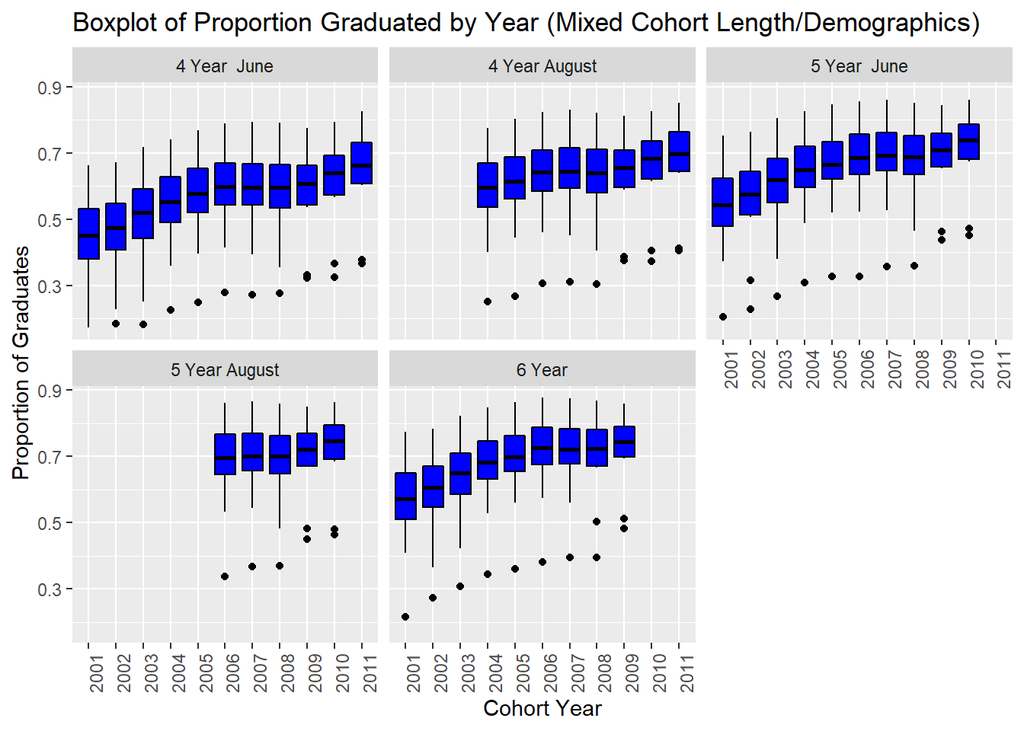

```r
# boxplot of proportion of all graduation rates by year and cohort length (mixed demographics)
ggplot(propMyData, aes(x=as.factor(cohort_year), y=prop_total_grads)) +
  geom_boxplot(color="black", fill="blue") +
  facet_wrap(~cohort_category) +
  labs(title="Boxplot of Proportion Graduated by Year (Mixed Cohort Length/Demographics)",
       x = "Cohort Year",
       y = "Proportion of Graduates") +
  theme(axis.text.x = element_text(angle = 90, hjust = 1))
```

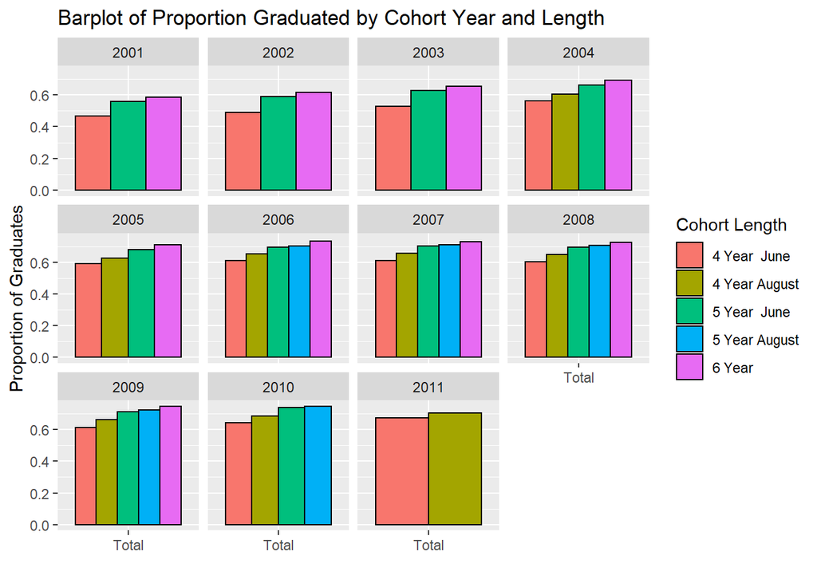

```r
# get total data from gender data set
totalData   <- filter(genderData, demographic=="Total")

# barplot of all graduation rates by cohort year by cohort length
ggplot(totalData, aes(x=demographic, y=prop_total_grads)) +
  geom_bar(aes(fill=as.factor(cohort_category)), position="dodge",
           color="black", stat="identity") +
  facet_wrap(~cohort_year) +
  labs(title="Barplot of Proportion Graduated by Cohort Year and Length",
       x = "",
       y = "Proportion of Graduates") +
  scale_fill_discrete(name="Cohort Length")
```

At a glance, the box plot data is able to show a general trend of increasing total graduation rates over time. This is a positive sign that suggests improvement in education outcomes in the state. The breakdown of graduation rates by cohort year and cohort length show (as expected) that proportion of total graduated increased with longer cohort length. However, since previous results have shown that total graduation rates appear to be changing over time, and since cohort length appears to have different availability by years, it is probably best to control for cohort length to prevent possible confounding between cohort year and cohort length. *As a result, further analysis will be restricted to only cohorts of length: 6 years.*

### Controlling for Cohort Length

Moving beyond exploratory data analysis, further analysis will be conducted restricted to a subset of only the 6 year cohort length studies in order to avoid potential bias among comparisons of different cohort years.

```r
# subset to only 6 year cohort
genderData6 <- genderData %>% filter(cohort_category=="6 Year")
raceData6   <- raceData   %>% filter(cohort_category=="6 Year")
```

### Checking for Missing Data

To check for a possible source of bias, the rates of missingness will be investigated (i.e. loss to follow-up) among cohort participants. The rates will be broken down by race to see if missingness may also provide some level of bias among the demographic variables. To handle repeated plotting of similar scatterplots, another custom function will be specified. Scatter plots of demograhpic by year for the indicated variables are shown. Curve fits (loess regression) with 95% confidence intervals are shown.

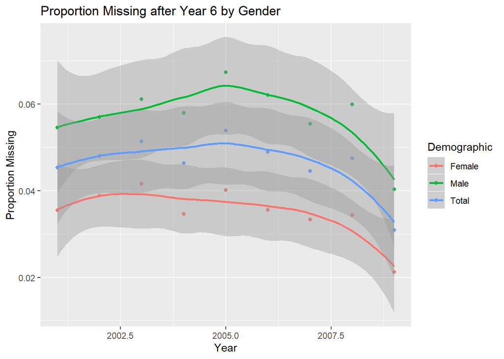

```r
# define custom function - plotDemoScatter
#   purpose: plots scatter plot by demographic with curve fitting
#   takes 5 arguments -
#     - data frame
#     - name of col that contains x-axis variable
#     - name of col that contains y-axis variable
#     - character string for title for scatter plot
#     - character string for y-axis label
#   returns invisible data frame
plotDemoScatter <- function(data, x, y, title, ylab){
  ggplot(data, aes_string(x=x, y=y)) +
    geom_point(aes(color=demographic)) +
    geom_smooth(aes(color=demographic)) +
    labs(title=title,
         x = "Year",
         y = ylab) +
    scale_color_discrete(name="Demographic")
  #invisible(data)
}

# plot of missing over time by gender
plotDemoScatter(genderData6, "cohort_year", "prop_missing",
                title="Proportion Missing after Year 6 by Gender",
                ylab="Proportion Missing")
```

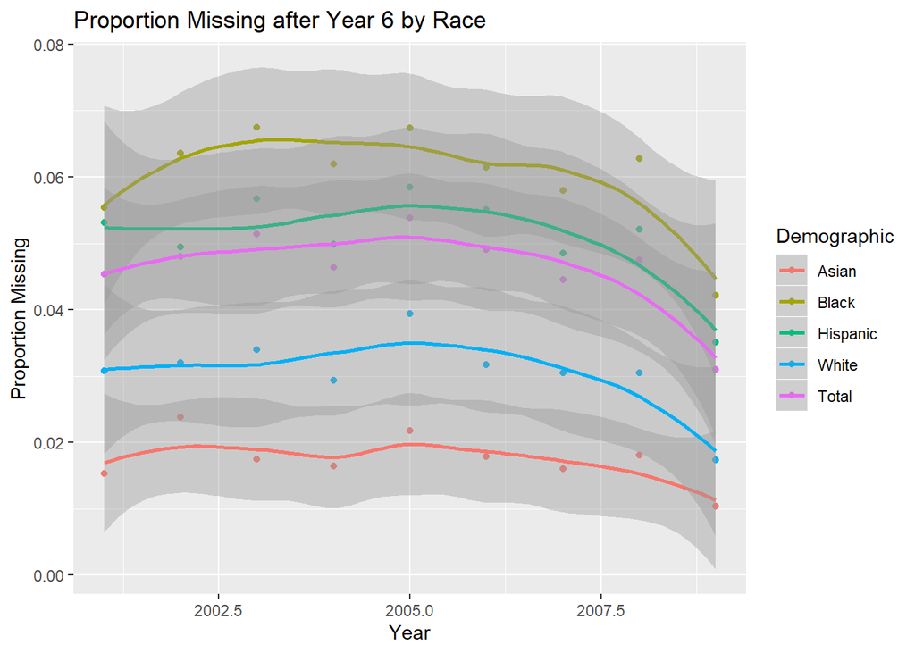

```r
# plot of missing over time by race
plotDemoScatter(raceData6, "cohort_year", "prop_missing",
                title="Proportion Missing after Year 6 by Race",
                ylab="Proportion Missing")
```

Interestingly, even among those restricted to the 6-year cohort length, the level of missigness (loss to follow-up) appears to be going possibly slightly down over time, suggesting a possible improvement in study methods as the study progressed. However, this dip may not be significant enough to be concerning. More concerning is the variation among levels of the racial demographic variable, which may be of more concern as a possible source of study bias.

## Data Analysis

After performing some exploratory data analysis, the end points of the study (graduation rates and drop out proportions) will be investigated. The following scatterplots will look at the variables, by race and gender separately, and among only participants in the 6-year cohort study. Scatter plots of demograhpic by year for the indicated variables are shown. Curve fits (loess regression) with 95% confidence intervals are shown.

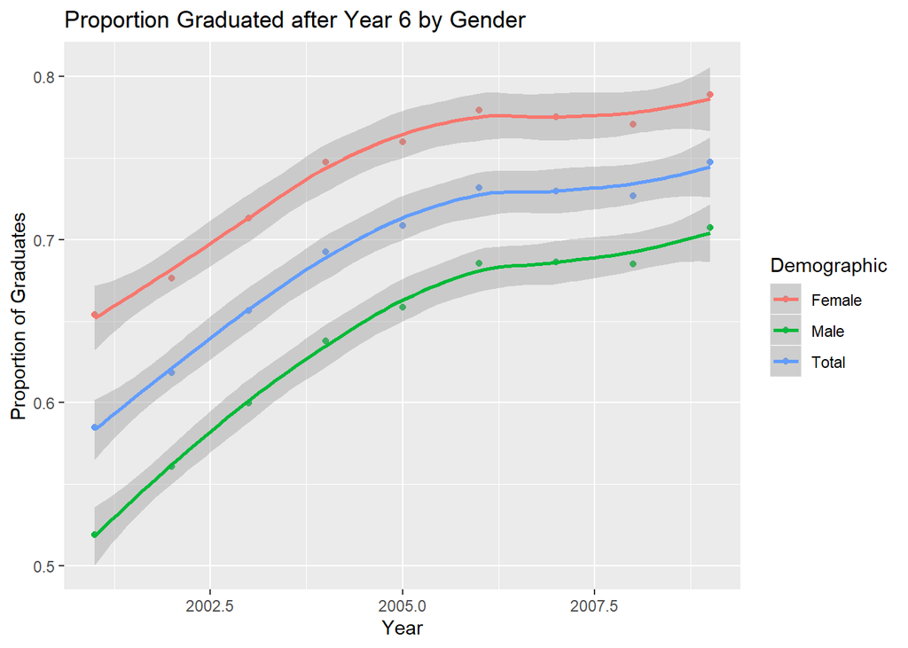

```r
# gender scatter plot of graduate proportion
plotDemoScatter(genderData6, "cohort_year", "prop_total_grads",
                title="Proportion Graduated after Year 6 by Gender",
                ylab="Proportion of Graduates")
```

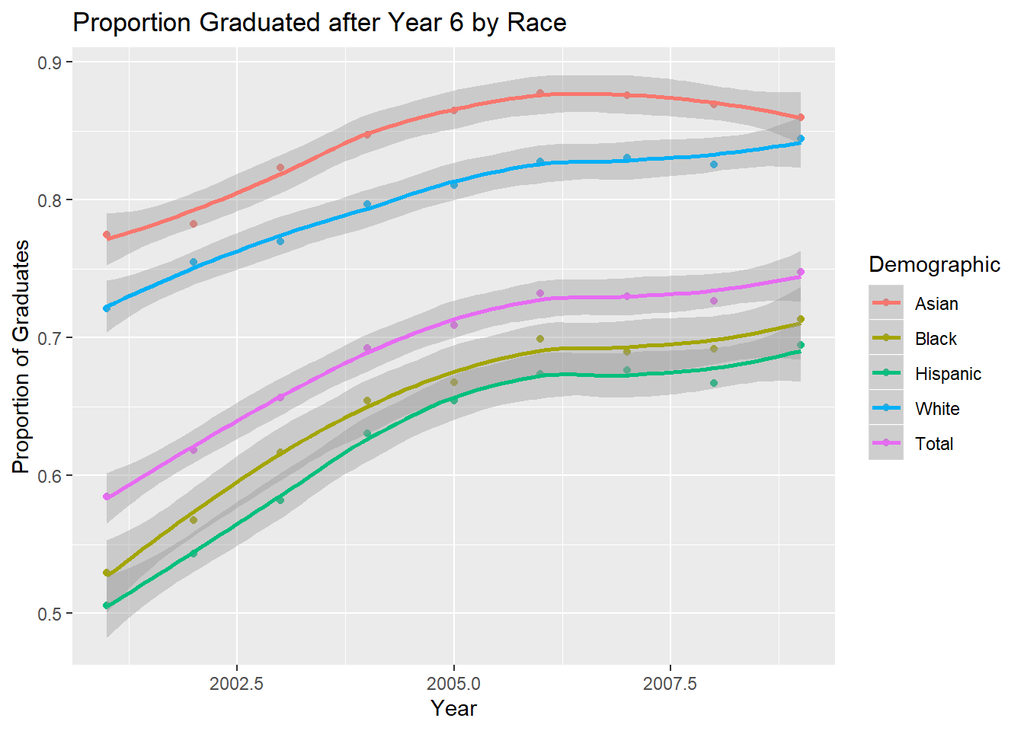

```r
# race scatter plot of graduate proportion
plotDemoScatter(raceData6, "cohort_year", "prop_total_grads",
                title="Proportion Graduated after Year 6 by Race",
                ylab="Proportion of Graduates")
```

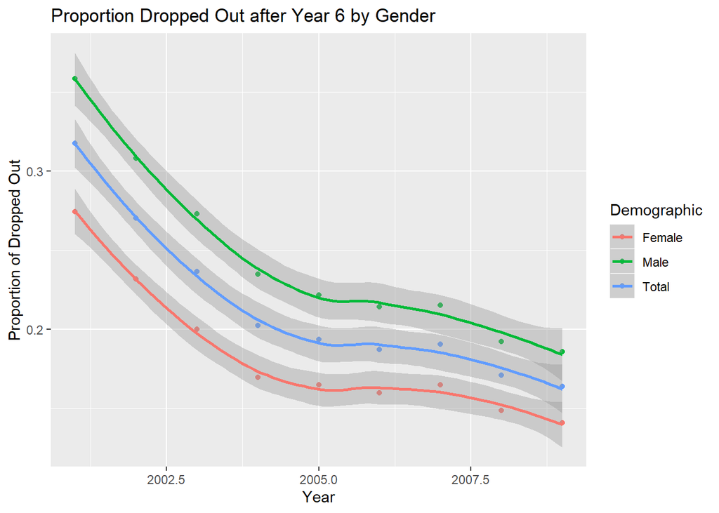

```r
# gender scatter plot of proportion of drop outs
plotDemoScatter(genderData6, "cohort_year", "prop_dropped_out",
                title="Proportion Dropped Out after Year 6 by Gender",
                ylab="Proportion of Dropped Out")
```

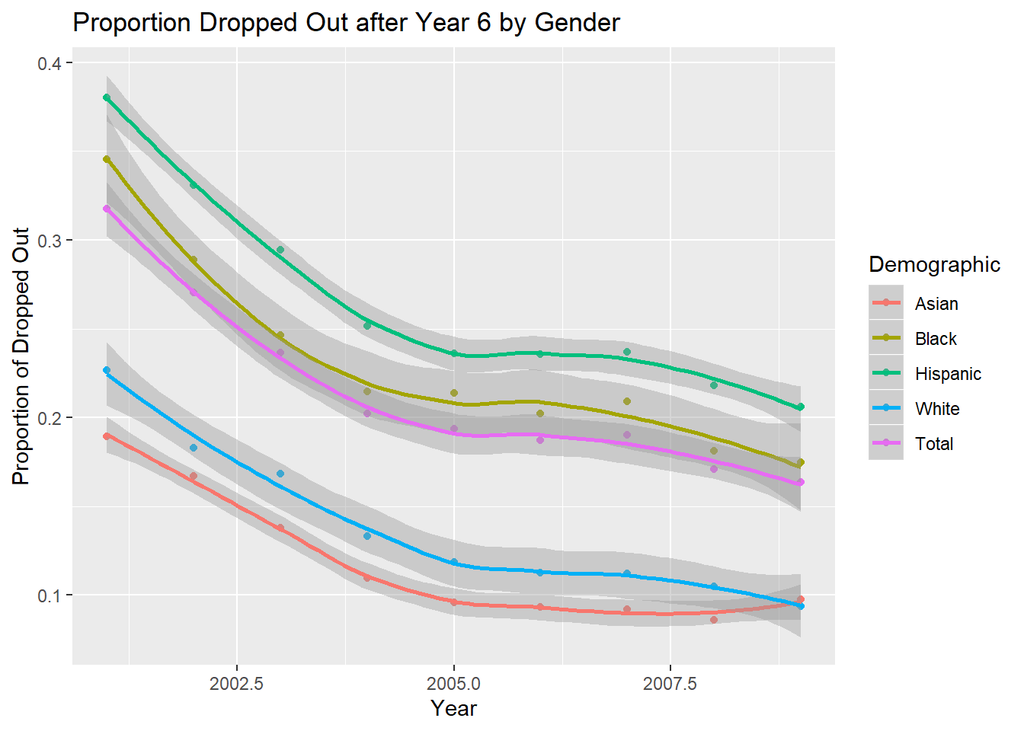

```r
# race scatter plot of proportion of drop outs
plotDemoScatter(raceData6, "cohort_year", "prop_dropped_out",
                title="Proportion Dropped Out after Year 6 by Gender",
                ylab="Proportion of Dropped Out")
```

# Discussion

As a whole, it appears that graduate rates are rising and drop out rates are falling among all groups. Fortunately, the improvements over time appear to be experienced by all demographic groups in what appears to be a fairly equal way. Unfortunately, it appears that men, black, and hispanics demographic groups are lagging behind in these metrics. Given the historically disadvantaged status of black and hispanic individuals in the US, this is an important result that may deserve additional investigation in these and other data.

As a future direction it would be interesting to do similar breakdowns by disability and english-speaking status. Given the lagging performance of minorities in graduation metrics, it seems likely that those who do not speak english as a first language would also be a particularly vulnerable group and would be likely to lag behind in other education metrics as well. Further follow-up could also investigate if the *rate of graduation* from cohort lengths year 4 to year 6 also differ between demographic groups. This would lend further evidence towards disparity in outcomes and also possibly add a further dimension to our understanding of this problem.